# Exploratory Data Analysis

Melbourne Housing Market

Last update: 2022-01-09

# Introducción

In this project for Mathematical Foundations of Data Analysis Course from the Big Data Master an Exploratory Data Analysis and Linear Regression Model is done using R and Melbourne Housing Market dataset.

This dataset can be downloaded from [this Kaggle website](https://www.kaggle.com/anthonypino/melbourne-housing-market):

The dataset includes data from houses sold in the real state market of Melbourne (Australia), price, address, suburb, number of rooms, real state agent…

## Preliminaries

- Cleaning working directory and loading required libraries:

```r
rm(list = ls())
library(tidyverse)
```

```r
library(leaflet)
library(corrplot)
library(GGally)
library(MLTools)
library(car)
library(caret)
```

- The dataset is loaded and stored in the variable housing:

```r
housing <- read_csv('data/Melbourne_housing_FULL.csv')
```

# Analysis of the dataset

## Variable types

The original dataset consists on 34857 observations distributed in 21 variables.

The distribution of the variables is shown by the command summary: if it is numeric or categorical, between which values it moves, it mean…

```r
summary(housing)
```

```
##     Suburb            Address              Rooms            Type
##  Length:34857       Length:34857       Min.   : 1.000   Length:34857
##  Class :character   Class :character   1st Qu.: 2.000   Class :character
##  Mode  :character   Mode  :character   Median : 3.000   Mode  :character
##                                        Mean   : 3.031
##                                        3rd Qu.: 4.000
##                                        Max.   :16.000
##
##      Price             Method            SellerG              Date
##  Min.   :   85000   Length:34857       Length:34857       Length:34857
##  1st Qu.:  635000   Class :character   Class :character   Class :character
##  Median :  870000   Mode  :character   Mode  :character   Mode  :character
##  Mean   : 1050173
##  3rd Qu.: 1295000
##  Max.   :11200000
##  NA's   :7610
##     Distance        Postcode       Bedroom2         Bathroom
##  Min.   : 0.00   Min.   :3000   Min.   : 0.000   Min.   : 0.000
##  1st Qu.: 6.40   1st Qu.:3051   1st Qu.: 2.000   1st Qu.: 1.000
##  Median :10.30   Median :3103   Median : 3.000   Median : 2.000
##  Mean   :11.18   Mean   :3116   Mean   : 3.085   Mean   : 1.625
##  3rd Qu.:14.00   3rd Qu.:3156   3rd Qu.: 4.000   3rd Qu.: 2.000
##  Max.   :48.10   Max.   :3978   Max.   :30.000   Max.   :12.000
##  NA's   :1       NA's   :1      NA's   :8217     NA's   :8226
##       Car            Landsize         BuildingArea       YearBuilt
##  Min.   : 0.000   Min.   :     0.0   Min.   :    0.0   Min.   :1196
##  1st Qu.: 1.000   1st Qu.:   224.0   1st Qu.:  102.0   1st Qu.:1940
##  Median : 2.000   Median :   521.0   Median :  136.0   Median :1970
##  Mean   : 1.729   Mean   :   593.6   Mean   :  160.3   Mean   :1965
##  3rd Qu.: 2.000   3rd Qu.:   670.0   3rd Qu.:  188.0   3rd Qu.:2000
##  Max.   :26.000   Max.   :433014.0   Max.   :44515.0   Max.   :2106
##  NA's   :8728     NA's   :11810      NA's   :21115     NA's   :19306
##  CouncilArea          Lattitude        Longtitude     Regionname
##  Length:34857       Min.   :-38.19   Min.   :144.4   Length:34857
##  Class :character   1st Qu.:-37.86   1st Qu.:144.9   Class :character
##  Mode  :character   Median :-37.81   Median :145.0   Mode  :character
##                     Mean   :-37.81   Mean   :145.0
##                     3rd Qu.:-37.75   3rd Qu.:145.1
##                     Max.   :-37.39   Max.   :145.5
##                     NA's   :7976     NA's   :7976
##  Propertycount
##  Min.   :   83
##  1st Qu.: 4385
##  Median : 6763
##  Mean   : 7573
##  3rd Qu.:10412
##  Max.   :21650
##  NA's   :3
```

Next, a description from each variable in the dataset is provided:

- Suburb: Neighborhood where the house is located (categorical)
- Address: Address of the house (categorical)
- Rooms: Number of rooms of the house (discrete)
- Type: house type (categorical) h - house, cottage, villa, semi, terrace u - unit, duplex t - townhouse
- Price: Price of the house in australian dollars (continuous)
- Method: Sell method of the house (categorical) S - property sold SP - property sold prior PI - property passed in PN - sold prior not disclosed SN - sold not disclosed VB - vendor bid; W - withdrawn prior to auction SA - sold after auction SS - sold after auction price not disclosed
- SellerG: Real state agent (categorical)
- Date: Sell date (categorical)
- Distance: Distance to Central Business District of Melbourne (continuous)
- Postcode: Postal code (categorical)
- Bedroom2: Number of rooms, data scraped from another source (discrete)
- Bathroom: Number of bathrooms (discrete)
- Car: Number of car spots (discrete)
- Landsize: Size of the terrain in meters (continuous)
- Building Area: Building size in meters (continuous)
- YearBuilt: Year the house was build (discrete)
- CouncilArea: Governing council for the area (categorical)
- Latitude: Latitude where the house is located (continuous)
- Longitude: Longitude where the house is located (continuous)
- Regionname: Region where the house is located (categorical)
- Propertycount: Number of houses in the Neighborhood (discrete)

## Missing values treatment (NAs)

As it was seen with summary, there are a few registers with NAs values in some of their variables, Tal y como se vio en el summary existen bastantes registros con valores NAs en alguna de sus variables, they are going to be eliminated according to different criteria.

All the NAs observations from column Price are deleted.

```r
housing = housing %>%
  drop_na(Price)
```

Now there is a total of 27247 observations, summary is executed to see the NAs distribution.

```r
summary(housing)
```

```
##     Suburb            Address              Rooms            Type
##  Length:27247       Length:27247       Min.   : 1.000   Length:27247
##  Class :character   Class :character   1st Qu.: 2.000   Class :character
##  Mode  :character   Mode  :character   Median : 3.000   Mode  :character
##                                        Mean   : 2.992
##                                        3rd Qu.: 4.000
##                                        Max.   :16.000
##
##      Price             Method            SellerG              Date
##  Min.   :   85000   Length:27247       Length:27247       Length:27247
##  1st Qu.:  635000   Class :character   Class :character   Class :character
##  Median :  870000   Mode  :character   Mode  :character   Mode  :character
##  Mean   : 1050173
##  3rd Qu.: 1295000
##  Max.   :11200000
##
##     Distance        Postcode       Bedroom2         Bathroom
##  Min.   : 0.00   Min.   :3000   Min.   : 0.000   Min.   :0.000
##  1st Qu.: 6.40   1st Qu.:3046   1st Qu.: 2.000   1st Qu.:1.000
##  Median :10.50   Median :3088   Median : 3.000   Median :1.000
##  Mean   :11.28   Mean   :3114   Mean   : 3.046   Mean   :1.592
##  3rd Qu.:14.00   3rd Qu.:3153   3rd Qu.: 4.000   3rd Qu.:2.000
##  Max.   :48.10   Max.   :3978   Max.   :20.000   Max.   :9.000
##  NA's   :1       NA's   :1      NA's   :6441     NA's   :6447
##       Car            Landsize         BuildingArea       YearBuilt
##  Min.   : 0.000   Min.   :     0.0   Min.   :    0.0   Min.   :1196
##  1st Qu.: 1.000   1st Qu.:   219.0   1st Qu.:  100.0   1st Qu.:1950
##  Median : 2.000   Median :   512.0   Median :  133.0   Median :1970
##  Mean   : 1.715   Mean   :   593.5   Mean   :  156.8   Mean   :1967
##  3rd Qu.: 2.000   3rd Qu.:   664.0   3rd Qu.:  182.0   3rd Qu.:2000
##  Max.   :18.000   Max.   :433014.0   Max.   :44515.0   Max.   :2019
##  NA's   :6824     NA's   :9265       NA's   :16591     NA's   :15163
##  CouncilArea          Lattitude        Longtitude     Regionname
##  Length:27247       Min.   :-38.19   Min.   :144.4   Length:27247
##  Class :character   1st Qu.:-37.86   1st Qu.:144.9   Class :character
##  Mode  :character   Median :-37.80   Median :145.0   Mode  :character
##                     Mean   :-37.81   Mean   :145.0
##                     3rd Qu.:-37.75   3rd Qu.:145.1
##                     Max.   :-37.40   Max.   :145.5
##                     NA's   :6254     NA's   :6254
##  Propertycount
##  Min.   :   83
##  1st Qu.: 4294
##  Median : 6567
##  Mean   : 7567
##  3rd Qu.:10412
##  Max.   :21650
##  NA's   :3
```

Decision to eliminate missing values in columns where there are little NA number is made.

```r
housing = housing %>%
  drop_na(Distance, Postcode, Propertycount)
```

Columns BuildingArea and Yearbuilt are deleted from the dataset because of the high percentage of NAs.

```r
housing$BuildingArea = NULL
housing$YearBuilt = NULL
```

It seems that the NAs observations in variables Car, Bathroom and Bedroom2 are the same (when an observation have one of these variables missing, have all of them). Additionally, variable Landsize have a high number of missing values. Observations with NAs in previous mentioned variables are deleted from the dataset.

```r
housing = housing %>%
  drop_na(Landsize, Car, Bathroom, Bedroom2)
```

Checking if there is anymore missing values in the dataset:

```r
apply(is.na(housing),2,which)
```

```
## $Suburb
## integer(0)
##
## $Address
## integer(0)
##
## $Rooms
## integer(0)
##
## $Type
## integer(0)
##
## $Price
## integer(0)
##
## $Method
## integer(0)
##
## $SellerG
## integer(0)
##
## $Date
## integer(0)
##
## $Distance
## integer(0)
##
## $Postcode
## integer(0)
##
## $Bedroom2
## integer(0)
##
## $Bathroom
## integer(0)
##
## $Car
## integer(0)
##
## $Landsize
## integer(0)
##
## $CouncilArea
## integer(0)
##
## $Lattitude
##  [1]  1541  1912  2736  3113  6567  8093  8588  8667  8673  8675  8676  9161
## [13]  9331  9508  9951 10071 10742 10746 11121 11453 11571 11716
##
## $Longtitude
##  [1]  1541  1912  2736  3113  6567  8093  8588  8667  8673  8675  8676  9161
## [13]  9331  9508  9951 10071 10742 10746 11121 11453 11571 11716
##
## $Regionname
## integer(0)
##
## $Propertycount
## integer(0)
```

There are 22 observations with common NAs in Lattitude and Longitude, so they are eliminated.

```r
housing = housing %>%
  drop_na(Lattitude, Longtitude)
```

It is verified that there are no longer any missing values in the table:

```r
any(is.na(housing))
```

```
## [1] FALSE
```

## Study of variables

### Address variable

See how many unique values the Address variable has in case it could be divided in some way:

```r
length(unique(housing$Address))
```

```
## [1] 17369
```

Address granularity is very high, groups of this column will give too many results, so the column is eliminated because it won’t provide useful information.

```r
housing$Address = NULL
```

### Suburb variable

This variable is converted to factor, showing how many levels it has and indicating in this way the number of suburbs within the houses are distributed.

```r
housing$Suburb = as.factor(housing$Suburb)
length(levels(housing$Suburb))
```

```
## [1] 333
```

### Variable Rooms

Absolute frequency is showed for Rooms variable, indicating how many houses are for each number of rooms. The values are distributed between 1 and 12, focusing among 1 and 5.

```r
table(housing$Rooms)
```

```
##
##    1    2    3    4    5    6    7    8   10   12
##  688 3944 7944 4105  875   96   14   10    2    1
```

### Variable Car

This variable indicates the number of car spots that a house have. The decision made is to transform it to factor and divide it into two levels: YES (if have car spot/s) or NO (don’t have car spot/s).

```r
housing$Car = as.factor(housing$Car)
levels(housing$Car) = c("NO", "YES", "YES", "YES", "YES", "YES", "YES", "YES", "YES", "YES", "YES", "YES", "YES", "YES", "YES")
levels(housing$Car)
```

```
## [1] "NO"  "YES"
```

### Regionname variable

Regioname is transformed to factor and it levels are showed, observing 8 levels.

```r
housing$Regionname = as.factor(housing$Regionname)
levels(housing$Regionname)
```

```
## [1] "Eastern Metropolitan"       "Eastern Victoria"
## [3] "Northern Metropolitan"      "Northern Victoria"
## [5] "South-Eastern Metropolitan" "Southern Metropolitan"
## [7] "Western Metropolitan"       "Western Victoria"
```

### SellerG variable

This variable is going to be studied in detail in order to discover who are the sellers that get more houses sold and where are these houses located.

Firstly, the number of houses sold for each seller and the percentage with respect to the total is computed. The 5 sellers with more houses sold is showed.

```r
TopSellers = housing %>%
  group_by(SellerG) %>%
  dplyr::summarise(numberofhouses_sold = n()) %>%
  mutate(percentageSold = round((numberofhouses_sold*100)/nrow(housing),2)) %>%
  arrange(desc(percentageSold))
head(TopSellers, 5)
```

```
## # A tibble: 5 x 3
##   SellerG       numberofhouses_sold percentageSold
##   <chr>                       <int>          <dbl>
## 1 Nelson                       1884          10.7
## 2 Jellis                       1638           9.27
## 3 Barry                        1550           8.77
## 4 hockingstuart                1373           7.77
## 5 Ray                           993           5.62
```

Nelson is the seller with more houses. Now, the number of houses sold by Nelson for each region and the probability of Nelson have sold a house in each one is computed.

```r
housing %>%
  filter(SellerG == "Nelson") %>%
  group_by(Regionname) %>%
  dplyr::summarise(houses_by_nelson = n()) %>%
  mutate(prob = round((houses_by_nelson / sum(houses_by_nelson)*100),2))
```

```
## # A tibble: 5 x 3
##   Regionname                 houses_by_nelson  prob
##   <fct>                                 <int> <dbl>
## 1 Eastern Metropolitan                    104  5.52
## 2 Northern Metropolitan                  1106 58.7
## 3 South-Eastern Metropolitan                2  0.11
## 4 Southern Metropolitan                    60  3.18
## 5 Western Metropolitan                    612 32.5
```

Next, a bar plot with the top 5 sellers is generated, showing how many where sold for each seller sorted from higher to lower value.

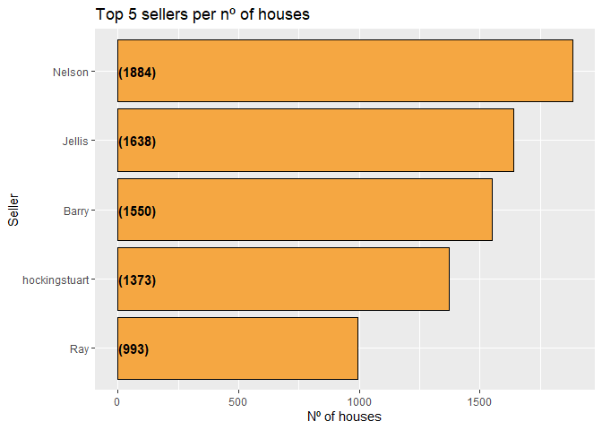

```r
sellerData = housing %>%
             group_by(SellerG) %>%
             dplyr::summarise(CountPerSeller = n()) %>%
             arrange(desc(CountPerSeller))

sellerData = sellerData[0:5,]

ggplot(sellerData, aes(x = reorder(SellerG, CountPerSeller),
                     y = CountPerSeller)) +
  geom_bar(stat='identity',colour="black", fill = '#f5a742') +
  geom_text(aes(x = SellerG, y = 1, label = paste0("(",CountPerSeller,")",sep="")),
            hjust=0, vjust=0.5, size = 4, colour = 'black',
            fontface = 'bold') +
  labs(x = 'Seller', y = 'Nº of houses', title = 'Top 5 sellers per nº of houses') +
  coord_flip()
```

Lastly, the houses sold by the top 5 sellers is plotted in a map (using leaflet library). Each point in the map is a house (located according to its values of Latitude and Longitude) and each color represents each one of the 5 sellers.

```r
Sellers = c(head(as.character(sellerData$SellerG),5))

SellersTop = housing %>%
  filter(SellerG %in% Sellers)

center_lon = median(SellersTop$Longtitude)
center_lat = median(SellersTop$Lattitude)

pal <- colorFactor(
  palette = c('red', 'blue', 'green', 'purple', 'black'),
  domain = SellersTop$SellerG
)

leaflet(SellersTop) %>% addTiles() %>%
  addCircles(lng = ~Longtitude, lat = ~Lattitude,radius = 3,
             color = ~pal(SellerG))  %>%
  addLegend("bottomright", pal = pal, values = ~SellerG,
    title = "House distribution Top 5 sellers",
    opacity = 1
  ) %>%
  # controls
  setView(lng=center_lon, lat=center_lat, zoom=10)
```

[interactive chart not shown]

# Variables study according with their relation with Price

- Studied how the Price change depending on the number of house’s Rooms. This is done by the next graphic, showing the average price of the houses depending on the number of rooms that it has.

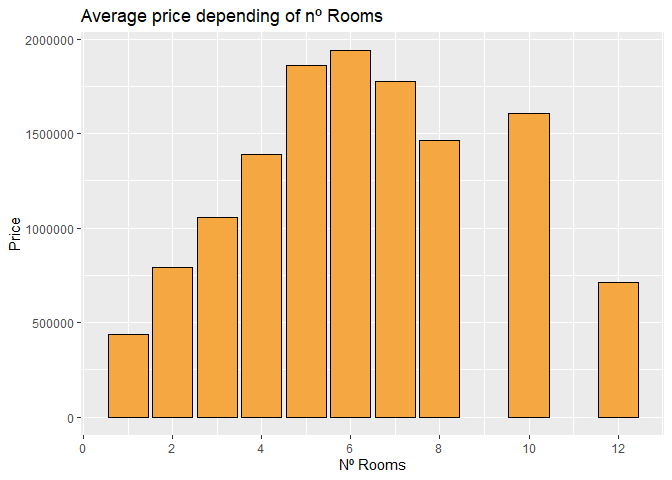

```r
roomData = housing %>%
  group_by(Rooms) %>%
  dplyr::summarise(AvgPricePerRoom = mean(Price)) %>%
  arrange(desc(Rooms))

ggplot(roomData, aes(x = Rooms,y = AvgPricePerRoom)) +
  scale_x_continuous(breaks=c(0,2,4,6,8,10,12,14,16,18,20)) +
  geom_bar(stat='identity',colour="black", fill = '#f5a742') +
  labs(x = 'Nº Rooms', y = 'Price', title = 'Average price depending of nº Rooms')
```

As it can be seen the price goes up as the number of rooms increase, until 6.

- Car variable is studied to see if houses’ average price change if they have car spot/s or not.

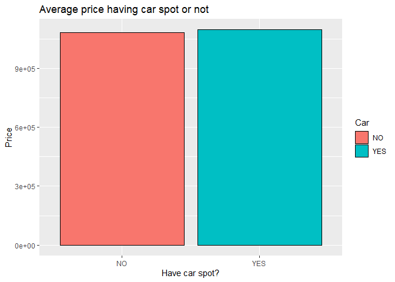

```r
carData = housing %>%
  group_by(Car) %>%
  dplyr::summarise(AvgPriceCar = mean(Price))

ggplot(carData, aes(x = Car,y = AvgPriceCar, fill = Car)) +
  geom_bar(stat='identity', color='black') +
  labs(x = 'Have car spot?', y = 'Price', title = 'Average price having car spot or not')
```

It seems that the price increases a little when there are car spots, but there isn’t a significant difference.

```r
suburbData = housing %>%
             group_by(Suburb) %>%
             dplyr::summarise(AvgPricePerSuburb = round(median(Price),0)) %>%
             arrange(desc(AvgPricePerSuburb))

suburbData$AvgPriceSuburb = scales::dollar(suburbData$AvgPricePerSuburb)
```

With the data from the most expensive Suburbs a bar plot is generated, showing the 10 more expensive and indicating their price and name.

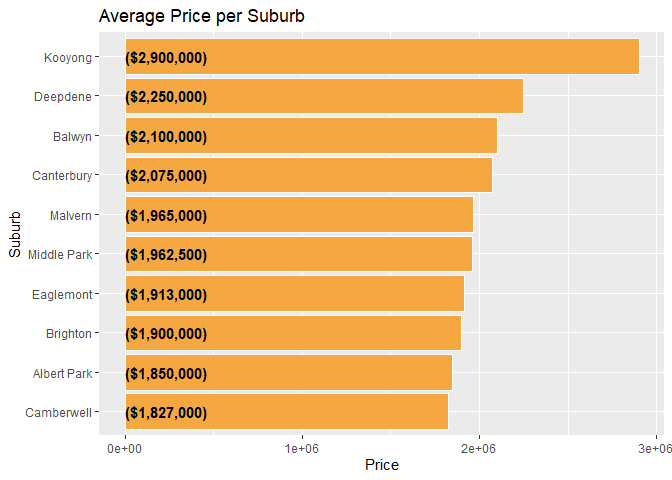

```r
suburbData = suburbData[0:10,]

ggplot(suburbData, aes(x = reorder(Suburb, AvgPricePerSuburb),
                     y = AvgPricePerSuburb)) +
  geom_bar(stat='identity',colour="white", fill = '#f5a742') +
  geom_text(aes(x = Suburb, y = 1, label = paste0("(",AvgPriceSuburb,")",sep="")),
            hjust=0, vjust=.5, size = 4, colour = 'black',
            fontface = 'bold') +
  labs(x = 'Suburb', y = 'Price', title = 'Average Price per Suburb') +
  coord_flip()
```

The rows corresponding to the top 10 most expensive suburbs are selected from the dataset and represented by their latitude and longitude in a map with leaflet library. Each dot on the map is a house and each color is a suburb. It can be seen where the most expensive properties from the city of Melbourne are situated.

```r
Suburbs = c(head(as.character(suburbData$Suburb),10))

SuburbsTop = housing %>%
  filter(Suburb %in% Suburbs)

center_lon = median(SuburbsTop$Longtitude)
center_lat = median(SuburbsTop$Lattitude)

pal <- colorFactor(
  palette = 'plasma',
  domain = SuburbsTop$Suburb
)

leaflet(SuburbsTop) %>% addTiles() %>%
  addCircles(lng = ~Longtitude, lat = ~Lattitude,radius = 3,
             color = ~pal(Suburb))  %>%
  addLegend("bottomright", pal = pal, values = ~Suburb,
    title = "House distribution Top 10 Suburbs",
    opacity = 1
  ) %>%
  # controls
  setView(lng=center_lon, lat=center_lat, zoom=11)
```

[interactive chart not shown]

- On the next plot, change of price is shown depending on the date when the house was sold. To do this, the date is represented on the X axis (converted to Date type) and on the Y axis the property selling price.

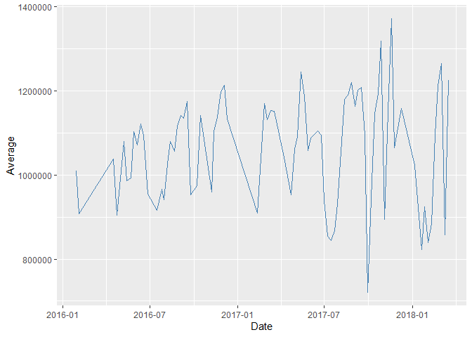

```r
housingDate = housing
housingDate$Date = as.Date(housingDate$Date,format = "%d/%m/%Y")
price_trend = housingDate %>%
  group_by(Date) %>%
  dplyr::summarise(Average = sum(Price)/n())

ggplot(price_trend, aes(x = Date, y = Average)) +
  geom_line(color = "steelblue")
```

It seems that prices are a little bit higher the later the date is, but there is not a concrete trend identified on price variance, probably because the time period is a little over two years.

- In the next figure it can be seen with boxplots how the price change and between what values depending on the region to which the house belongs.

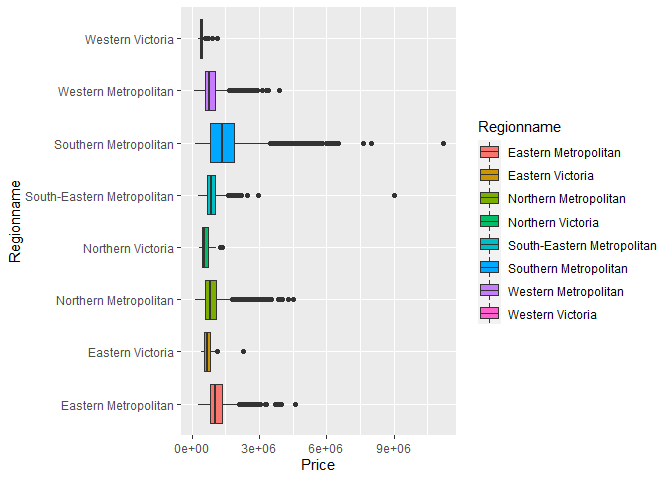

```r
housing %>%
  ggplot(aes(x=Regionname, y = Price, fill=Regionname)) +
  geom_boxplot()+
  coord_flip()
```

There are regions whose prices are higher than others, Southern Metropolitan (represented in blue) seems to be the most expensive region.

- The variance of price according to the type of house is as well represented with boxplots of different colors.

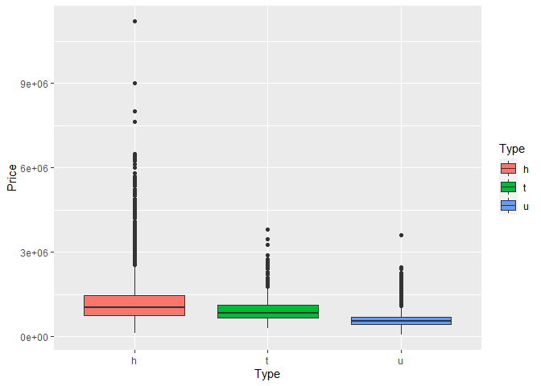

```r
housing %>%
  ggplot(aes(x=Type, y = Price, fill=Type)) +
  geom_boxplot()
```

As it can be seen, the house Type influence clearly on the price value, being higher for type h (house) than for ype u (unit). It’s higher for a house than for an apartment.

- Same type of plot is done for the Method variable versus Price, to see it influence and if they have any relation.

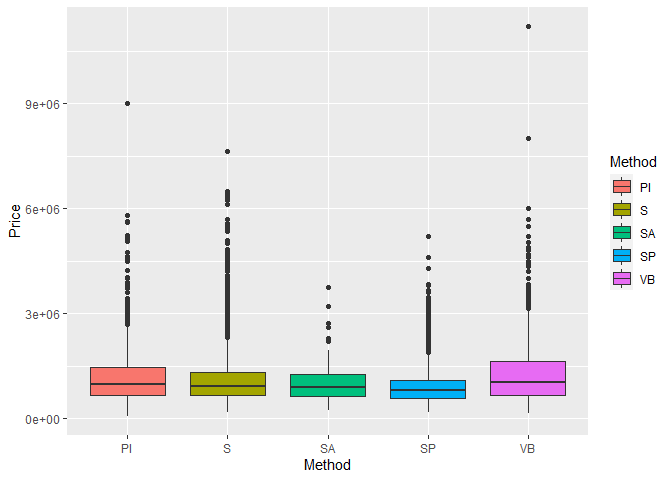

```r
housing %>%
  ggplot(aes(x=Method, y = Price, fill=Method)) +
  geom_boxplot()
```

- Now, variable Distance is analyzed, this variable indicate the distance of the house to the Melbourne Business District and is plotted with the Price variable using a geom point diagram.

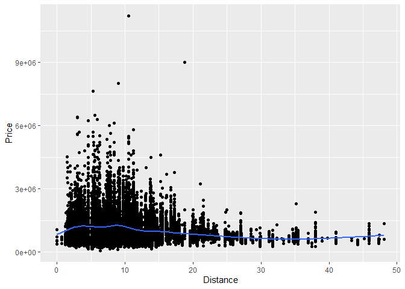

```r
housing %>%
  ggplot(data = housing, mapping = aes(x = Distance, y = Price)) +
  geom_point() +
  geom_smooth(se = FALSE)
```

- Lastly, it is analyzed how the variable Price is distributed using an histogram and a density curve.

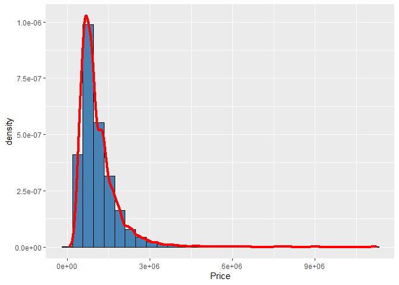

```r
housing %>%
  ggplot(aes(x=Price))+
  geom_histogram(aes(y=stat(density)), fill="steelblue", color = "black") +
  geom_density(color="red", size=1.5)
```

Values are concentrated on million dollar houses, the higher the price is, less houses are with very high value.

# Price prediction Linear Regression model

According to the previous analysis, a set of the most relevant variables to the price are selected for training a linear regression model to predict Price variable.

From the initial 21 variables, 13 are selected to predict the price of the houses. The reasons to put aside the variables is:

- BuildingArea and Yearbuilt columns are deleted because of the high percentage of NAs.
- Address granularity is very high, grouping this variable will produce a lot of results.
- Suburb, CouncilArea and Date have the same granularity problem as Address, Regioname is selected as geographical variable with enough registers in the factor levels.
- Bedroom2 variable is correlated with Rooms and has some NAs so, Rooms is selected in terms of reliability.
- SellerG causes some problems when is included in the model as a factor because there are not enough registers in each level of the variable and generates a very high number of factors.

Variable fdata contains the set of variables selected.

```r
fdata = select(housing, Rooms , Type , Method , Distance ,
    Postcode , Bathroom , Car , Landsize , Regionname,
    Lattitude , Longtitude , Propertycount, Price)
```

Here a correlation plot between numerical variables is plotted.

As it can be observed Rooms, Bathroom, Distance, Lattitude and Longitude are the most correlated with Price variable.

Distance variable presents negative correlation with Price, higher distance from the Melbourne Business District means less price, and vice versa.

Rooms and Bathroom also have high correlation between them, when the number of rooms of the house is high, the number of bathrooms is too.

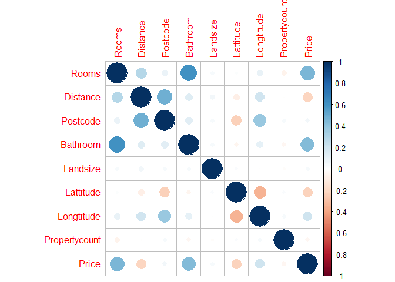

```r
numvars <- sapply(fdata, class) %in% c("integer","numeric")
C <- cor(fdata[,numvars])
corrplot::corrplot(C, method = "circle")
```

For training the model, Rooms column is changed to factor because there is a similar behavior in Price for the houses with 7 or more rooms, these houses are grouped when changing the variable to factor.

```r
fdata$Rooms <- as.factor(fdata$Rooms)
levels(fdata$Rooms) = c("1", "2", "3", "4", "5", "6", "7+", "7+", "7+", "7+")
levels(fdata$Rooms)
```

```
## [1] "1"  "2"  "3"  "4"  "5"  "6"  "7+"
```

To group the registers and convert the variable to factor, same procedure is done for Bathroom variable.

```r
fdata$Bathroom <- as.factor(fdata$Bathroom)
levels(fdata$Bathroom) = c("0","1", "2", "3", "4", "5", "6+", "6+", "6+", "6+")
levels(fdata$Bathroom)
```

```
## [1] "0"  "1"  "2"  "3"  "4"  "5"  "6+"
```

```r
table(fdata$Bathroom)
```

```
##
##    0    1    2    3    4    5   6+
##   34 9080 7055 1299  154   43   14
```

Studying Landsize variable numerous outliers that could influence negatively on the model predictions are detected.Outliers are stored in variable landsize_outliers.

```r
bxp_landsize <- boxplot(fdata$Landsize, plot = FALSE)
landsize_outliers <- bxp_landsize$out
```

There are outliers higher than 50000 that are eliminated from the dataset:

```r
fdata = fdata %>%
  filter(Landsize < 50000)
```

Finally, the linear regression model is trained using train and lm functions.

Creating training and test sets with a random distribution 80/20 of the samples.

```r
set.seed(150) # For replication
trainIndex <- createDataPartition(fdata$Price,   #createDataPartition creates proportional partitions
                                  p = 0.8,      #split probability for training
                                  list = FALSE, #Avoid output as a list
                                  times = 1)    #only one partition
#obtain training and validation sets
fTR <- fdata[trainIndex,]
fTS <- fdata[-trainIndex,]
```

Cross-validation is added with 10 folds.

```r
ctrl_tune <- trainControl(method = "cv",
                          number = 10,
                          summaryFunction = defaultSummary,    #Performance summary for comparing models in hold-out samples
                          returnResamp = "final",              #Return final information about resampling
                          savePredictions = TRUE)              #save predictions
```

Fitting the linear regression model for the training set:

```r
set.seed(150)
lm.fit = train(form = Price~.,
               data = fTR,
               method = "lm",
               tuneGrid = data.frame(intercept = TRUE),
               preProcess = c("center","scale"),
               trControl = ctrl_tune,
               metric = "RMSE")
lm.fit #information about the resampling settings
```

```
## Linear Regression
##
## 14140 samples
##    12 predictor
##
## Pre-processing: centered (32), scaled (32)
## Resampling: Cross-Validated (10 fold)
## Summary of sample sizes: 12726, 12727, 12727, 12725, 12725, 12726, ...
## Resampling results:
##
##   RMSE      Rsquared   MAE
##   420205.8  0.5948046  276638.1
##
## Tuning parameter 'intercept' was held constant at a value of TRUE
```

```r
summary(lm.fit)  #information about the model trained
```

```
##
## Call:
## lm(formula = .outcome ~ ., data = dat)
##
## Residuals:
##      Min       1Q   Median       3Q      Max
## -1889782  -231451   -51023   157961  9092336
##
## Coefficients:
##                                        Estimate Std. Error t value Pr(>|t|)
## (Intercept)                             1095529       3526 310.677  < 2e-16 ***
## Rooms2                                   115671       8438  13.708  < 2e-16 ***
## Rooms3                                   244652      11049  22.143  < 2e-16 ***
## Rooms4                                   290307      10266  28.278  < 2e-16 ***
## Rooms5                                   179834       6343  28.352  < 2e-16 ***
## Rooms6                                    70078       4031  17.385  < 2e-16 ***
## `Rooms7+`                                 16610       3780   4.394 1.12e-05 ***
## Typet                                    -87340       3724 -23.456  < 2e-16 ***
## Typeu                                   -206035       4766 -43.226  < 2e-16 ***
## MethodS                                   29372       5365   5.474 4.47e-08 ***
## MethodSA                                   1634       3633   0.450 0.652978
## MethodSP                                   5580       4817   1.158 0.246768
## MethodVB                                  12986       4509   2.880 0.003983 **
## Distance                                -308984       5571 -55.463  < 2e-16 ***
## Postcode                                  34762       5020   6.924 4.57e-12 ***
## Bathroom1                                 36946      39634   0.932 0.351252
## Bathroom2                                 97193      38955   2.495 0.012606 *
## Bathroom3                                120661      21226   5.685 1.34e-08 ***
## Bathroom4                                115254       8136  14.165  < 2e-16 ***
## Bathroom5                                 61615       5263  11.708  < 2e-16 ***
## `Bathroom6+`                              34055       4404   7.733 1.12e-14 ***
## CarYES                                    11358       3753   3.026 0.002479 **
## Landsize                                  31995       3616   8.848  < 2e-16 ***
## `RegionnameEastern Victoria`               8327       4062   2.050 0.040402 *
## `RegionnameNorthern Metropolitan`        -68639       7607  -9.023  < 2e-16 ***
## `RegionnameNorthern Victoria`             27448       4155   6.607 4.07e-11 ***
## `RegionnameSouth-Eastern Metropolitan`    13139       5227   2.514 0.011955 *
## `RegionnameSouthern Metropolitan`        126877       7225  17.560  < 2e-16 ***
## `RegionnameWestern Metropolitan`         -70721       9046  -7.818 5.76e-15 ***
## `RegionnameWestern Victoria`              16340       4252   3.843 0.000122 ***
## Lattitude                                -62982       5799 -10.862  < 2e-16 ***
## Longtitude                                44274       7114   6.223 5.01e-10 ***
## Propertycount                              6574       3767   1.745 0.080975 .
## ---
## Signif. codes:  0 '***' 0.001 '**' 0.01 '*' 0.05 '.' 0.1 ' ' 1
##
## Residual standard error: 419300 on 14107 degrees of freedom
## Multiple R-squared:  0.5977, Adjusted R-squared:  0.5968
## F-statistic:   655 on 32 and 14107 DF,  p-value: < 2.2e-16
```

```r
#Evaluate the model with training sets and diagnosis
fTR_eval = fTR
fTR_eval$lm_pred = predict(lm.fit,  newdata = fTR)
fTS_eval = fTS
fTS_eval$lm_pred = predict(lm.fit,  newdata = fTS)
```

Looking at the model results, it can be observed that all the variables selected are important (little p-value), except variables MethodSA, MethodSP, Bathroom1 and Propertycount. A R-squared error of 0.5977 is obtained.

On the next plot, the residuals from the trained model can be observed:

```
## [1] "Residuals vs  Rooms"
## [1] "Residuals vs  Type"
## [1] "Residuals vs  Method"
## [1] "Residuals vs  Distance"
## [1] "Residuals vs  Postcode"
## [1] "Residuals vs  Bathroom"
## [1] "Residuals vs  Car"
## [1] "Residuals vs  Landsize"
## [1] "Residuals vs  Regionname"
## [1] "Residuals vs  Lattitude"
## [1] "Residuals vs  Longtitude"
## [1] "Residuals vs  Propertycount"
## [1] "Residuals vs  Price"
```

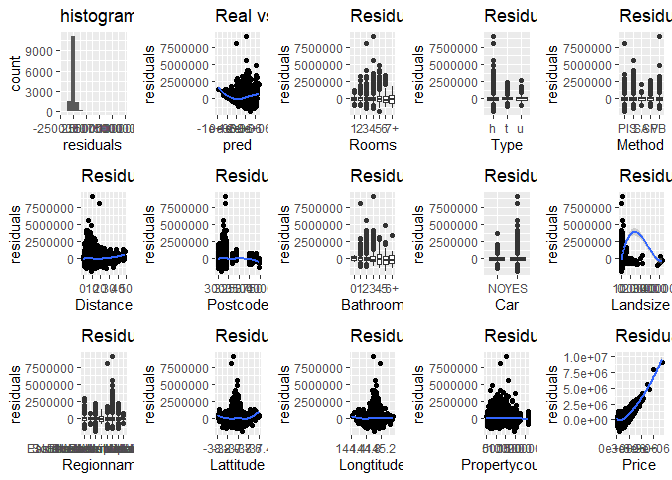

```r
PlotModelDiagnosis(fTR, fTR$Price, fTR_eval$lm_pred,
                   together = TRUE)
```

Landsize and Price residuals stand out for making mistakes with predictions of house with higher price and terrain.

In general the model make more mistakes with the cheapest houses predicting a higher value. It also make mistakes with the most expensive houses, what means that the model do wrong in the extremes. For intermediate price houses the model has higher capability for predicting well.

Computing RMSE error for the training and test set:

```r
caret::RMSE(fTR_eval$lm_pred,fTR_eval$Price)
```

```
## [1] 418824.1
```

```r
caret::RMSE(fTS_eval$lm_pred,fTS_eval$Price)
```

```
## [1] 408011.4
```

Training the model also with lm function to check the results obtained.

```r
model_l <- lm(Price ~ .,data = fTR)
summary(model_l)
```

```
##
## Call:
## lm(formula = Price ~ ., data = fTR)
##
## Residuals:
##      Min       1Q   Median       3Q      Max
## -1889782  -231451   -51023   157961  9092336
##
## Coefficients:
##                                        Estimate Std. Error t value Pr(>|t|)
## (Intercept)                          -8.171e+07  9.099e+06  -8.979  < 2e-16 ***
## Rooms2                                2.780e+05  2.028e+04  13.708  < 2e-16 ***
## Rooms3                                4.917e+05  2.221e+04  22.143  < 2e-16 ***
## Rooms4                                6.864e+05  2.427e+04  28.278  < 2e-16 ***
## Rooms5                                8.399e+05  2.962e+04  28.352  < 2e-16 ***
## Rooms6                                9.229e+05  5.309e+04  17.385  < 2e-16 ***
## Rooms7+                               3.954e+05  8.997e+04   4.394 1.12e-05 ***
## Typet                                -3.359e+05  1.432e+04 -23.456  < 2e-16 ***
## Typeu                                -5.467e+05  1.265e+04 -43.226  < 2e-16 ***
## MethodS                               6.179e+04  1.129e+04   5.474 4.47e-08 ***
## MethodSA                              1.894e+04  4.212e+04   0.450 0.652978
## MethodSP                              1.679e+04  1.449e+04   1.158 0.246768
## MethodVB                              4.462e+04  1.549e+04   2.880 0.003983 **
## Distance                             -4.645e+04  8.375e+02 -55.463  < 2e-16 ***
## Postcode                              3.144e+02  4.541e+01   6.924 4.57e-12 ***
## Bathroom1                             7.392e+04  7.929e+04   0.932 0.351252
## Bathroom2                             1.985e+05  7.956e+04   2.495 0.012606 *
## Bathroom3                             4.594e+05  8.081e+04   5.685 1.34e-08 ***
## Bathroom4                             1.262e+06  8.906e+04  14.165  < 2e-16 ***
## Bathroom5                             1.277e+06  1.091e+05  11.708  < 2e-16 ***
## Bathroom6+                            1.083e+06  1.400e+05   7.733 1.12e-14 ***
## CarYES                                4.575e+04  1.512e+04   3.026 0.002479 **
## Landsize                              2.921e+01  3.302e+00   8.848  < 2e-16 ***
## RegionnameEastern Victoria            1.071e+05  5.225e+04   2.050 0.040402 *
## RegionnameNorthern Metropolitan      -1.516e+05  1.680e+04  -9.023  < 2e-16 ***
## RegionnameNorthern Victoria           3.593e+05  5.438e+04   6.607 4.07e-11 ***
## RegionnameSouth-Eastern Metropolitan  6.373e+04  2.535e+04   2.514 0.011955 *
## RegionnameSouthern Metropolitan       2.737e+05  1.559e+04  17.560  < 2e-16 ***
## RegionnameWestern Metropolitan       -1.703e+05  2.179e+04  -7.818 5.76e-15 ***
## RegionnameWestern Victoria            2.753e+05  7.163e+04   3.843 0.000122 ***
## Lattitude                            -7.011e+05  6.455e+04 -10.862  < 2e-16 ***
## Longtitude                            3.805e+05  6.114e+04   6.223 5.01e-10 ***
## Propertycount                         1.491e+00  8.543e-01   1.745 0.080975 .
## ---
## Signif. codes:  0 '***' 0.001 '**' 0.01 '*' 0.05 '.' 0.1 ' ' 1
##
## Residual standard error: 419300 on 14107 degrees of freedom
## Multiple R-squared:  0.5977, Adjusted R-squared:  0.5968
## F-statistic:   655 on 32 and 14107 DF,  p-value: < 2.2e-16
```

Now, VIF is computed for the variables of the model. Regioname has a high value, meaning that there is colineality with another variable, deleting it from the model was tested but, after checking the results, the decision is to keep the variable because is significant to the model and results in better predictions.

```r
vif(model_l)
```

```
##                    GVIF Df GVIF^(1/(2*Df))
## Rooms          3.529471  6        1.110817
## Type           1.930625  2        1.178758
## Method         1.082549  4        1.009964
## Distance       2.495743  1        1.579792
## Postcode       2.026640  1        1.423601
## Bathroom       2.245886  6        1.069750
## Car            1.132710  1        1.064288
## Landsize       1.051533  1        1.025443
## Regionname    25.711096  7        1.261023
## Lattitude      2.703930  1        1.644363
## Longtitude     4.069959  1        2.017414
## Propertycount  1.140987  1        1.068170
```

### Diagnosis of the model

In this section some graphics are showed to check how accurate is the model with it predictions.

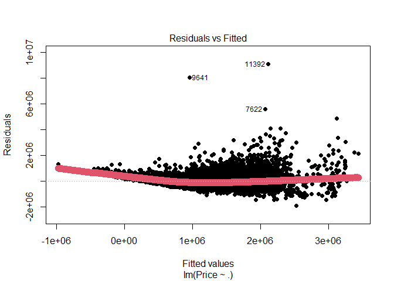

```r
plotModel = plot(model_l, which = 1, pch=19, lwd= 12)
```

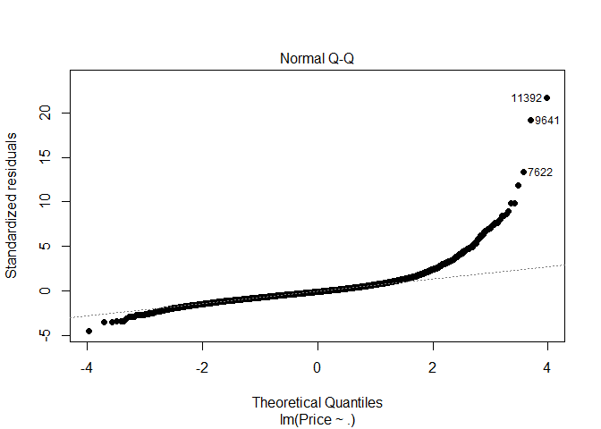

```r
plotModel = plot(model_l, which = 2, pch=19)
```

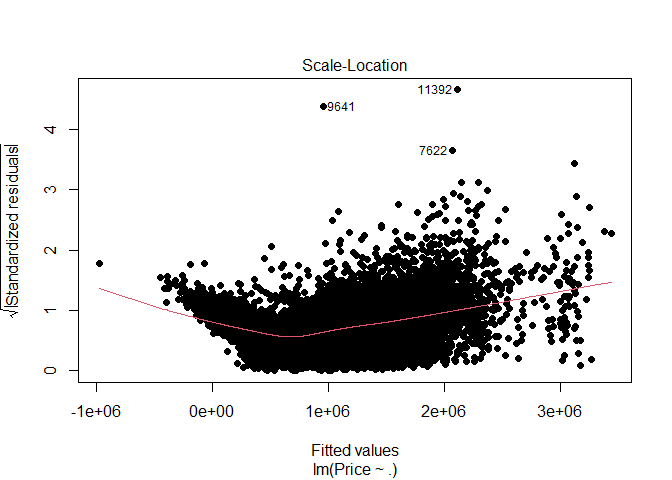

```r
plotModel = plot(model_l, which = 3, pch=19)
```

Lastly, with the Scale-Location graphic the visualization of cloud of dots width seems to be more or less homogeneous, but the red line is not that horizontal because a lack of homogeneity of variances.

# Conclusion

Throughout the document an exhaustive analysis of the variables in the dataset of houses sold in the city of Melbourne is done, providing graphs, interesting relationships between them and even including maps of the distribution of houses due to their location attending different terms.

Also, it has been studied how some of the variables have more influence than others in making the price of houses increase or decrease.

Finally, a linear regression model that provides price predictions for housing data has been trained. This model despite not having a perfect precision can offer quite successful price values for a new house in the city of Melbourne.